# Predicting Weight Lifting Exercise Quality

Love Vaishnav

2026-10-27

## Question and data

The task is to predict **how** a participant performed a barbell lift. The outcome `classe` has five categories (A to E). I used the [provided training data](https://d396qusza40orc.cloudfront.net/predmachlearn/pml-training.csv) for model building and kept the [20-case test set](https://d396qusza40orc.cloudfront.net/predmachlearn/pml-testing.csv) for the final quiz predictions. The original [Weight Lifting Exercises data source](https://web.archive.org/web/20161224072740/http://groupware.les.inf.puc-rio.br/har) describes the sensor study.

## Prepare the data

These commands download the CSV files only if they are absent from the current project folder. Blank values, `NA`, and `#DIV/0!` are treated as missing.

```r
train_url <- "https://d396qusza40orc.cloudfront.net/predmachlearn/pml-training.csv"
test_url  <- "https://d396qusza40orc.cloudfront.net/predmachlearn/pml-testing.csv"

if (!file.exists("pml-training.csv")) {
  download.file(train_url, "pml-training.csv", mode = "wb", quiet = TRUE)
}
if (!file.exists("pml-testing.csv")) {
  download.file(test_url, "pml-testing.csv", mode = "wb", quiet = TRUE)
}

training <- read.csv("pml-training.csv",
                     na.strings = c("NA", "", "#DIV/0!"))
testing <- read.csv("pml-testing.csv",
                    na.strings = c("NA", "", "#DIV/0!"))
stopifnot("classe" %in% names(training), nrow(testing) == 20)
training$classe <- factor(training$classe)

# Row identifiers, participant names, dates and window labels are not sensor
# measurements. Exclude them to avoid learning a shortcut unrelated to motion.
metadata <- c("X", "user_name", "raw_timestamp_part_1",
              "raw_timestamp_part_2", "cvtd_timestamp", "new_window",
              "num_window", "problem_id")
shared <- setdiff(intersect(names(training), names(testing)), metadata)

# Use only numeric sensor columns that have values in every row of both sets.
complete_numeric <- function(nm) {
  is.numeric(training[[nm]]) && is.numeric(testing[[nm]]) &&
    all(is.finite(training[[nm]])) && all(is.finite(testing[[nm]]))
}
predictors <- shared[vapply(shared, complete_numeric, logical(1))]
stopifnot(length(predictors) > 0)

# Remove constant or nearly constant predictors based on training data only.
nzv <- caret::nearZeroVar(training[, predictors, drop = FALSE])
if (length(nzv) > 0) predictors <- predictors[-nzv]
stopifnot(length(predictors) > 0)

data.frame(training_rows = nrow(training), test_rows = nrow(testing),
           sensor_predictors = length(predictors))
```

```
##   training_rows test_rows sensor_predictors
## 1         19622        20                52
```

This leaves 52 complete numeric sensor predictors. I did not use the 20 test cases to tune the model or estimate accuracy, because their true labels are unavailable.

## Cross validation and model selection

I used a stratified 75% split for model development and reserved 25% as an untouched validation set. Within the development set, three-fold cross validation compared two values of `mtry`, the number of sensor variables considered at each random forest split. Accuracy selected the better value. The random seed makes the split and fitting repeatable.

```r
set.seed(2026)
development_rows <- caret::createDataPartition(training$classe, p = 0.75,
                                               list = FALSE)
development <- training[development_rows, , drop = FALSE]
validation <- training[-development_rows, , drop = FALSE]

mtry_values <- sort(unique(pmin(length(predictors), c(6L, 12L))))
folds <- caret::trainControl(method = "cv", number = 3,
                            allowParallel = FALSE)
set.seed(2026)
cv_model <- caret::train(
  x = development[, predictors, drop = FALSE],
  y = development$classe,
  method = "rf",
  trControl = folds,
  tuneGrid = data.frame(mtry = mtry_values),
  metric = "Accuracy",
  ntree = 150
)

knitr::kable(cv_model$results[, c("mtry", "Accuracy", "AccuracySD")],
             digits = 4, caption = "Accuracy across the three folds")
```

Accuracy across the three folds

| mtry | Accuracy | AccuracySD |
| --- | --- | --- |
| 6 | 0.9899 | 0.0018 |
| 12 | 0.9912 | 0.0018 |

The selected `mtry` is 12. The folds estimate model performance inside the development set; the separate validation set gives a more direct check of the selected model.

## Validation and expected error

```r
validation_pred <- predict(cv_model,
                           newdata = validation[, predictors, drop = FALSE])
cm <- caret::confusionMatrix(validation_pred, validation$classe)
accuracy <- unname(cm$overall["Accuracy"])
error_rate <- 1 - accuracy

knitr::kable(as.data.frame.matrix(cm$table),
             caption = "Validation confusion matrix: predicted class by actual class")
```

Validation confusion matrix: predicted class by actual class

|  | A | B | C | D | E |
| --- | --- | --- | --- | --- | --- |
| A | 1394 | 5 | 0 | 0 | 0 |
| B | 1 | 943 | 4 | 0 | 0 |
| C | 0 | 1 | 850 | 4 | 2 |
| D | 0 | 0 | 1 | 799 | 0 |
| E | 0 | 0 | 0 | 1 | 899 |

```r
data.frame(validation_cases = nrow(validation),
           accuracy = round(accuracy, 4),
           estimated_error_rate = round(error_rate, 4))
```

```
##   validation_cases accuracy estimated_error_rate
## 1             4904   0.9961               0.0039
```

The model correctly classified 4885 of 4904 reserved records. Validation accuracy was 99.61%; the estimated out-of-sample error was 0.39%. This estimate applies most directly to similar records from this study. Since the same six people can appear in both portions of a row-level split, accuracy for entirely new people could be lower.

## Final model and 20 quiz answers

With the settings chosen above, I refitted the forest on all labeled rows. The 20 test records were used only here, after the validation result was fixed.

```r
set.seed(2026)
final_model <- randomForest::randomForest(
  x = training[, predictors, drop = FALSE],
  y = training$classe,
  mtry = cv_model$bestTune$mtry,
  ntree = 150,
  importance = TRUE
)
quiz_prediction <- predict(final_model,
                           newdata = testing[, predictors, drop = FALSE],
                           type = "class")

quiz_id <- if ("problem_id" %in% names(testing)) {
  testing$problem_id
} else {
  seq_len(nrow(testing))
}
answers <- data.frame(problem_id = quiz_id,
                      prediction = as.character(quiz_prediction))
stopifnot(nrow(answers) == 20, all(answers$prediction %in% levels(training$classe)))
write.csv(answers, "predictions.csv", row.names = FALSE)
writeLines(answers$prediction, "prediction_answers.txt")

knitr::kable(answers, caption = "Submit these predictions in problem order")
```

Submit these predictions in problem order

| problem_id | prediction |
| --- | --- |
| 1 | B |
| 2 | A |
| 3 | B |
| 4 | A |
| 5 | A |
| 6 | E |
| 7 | D |
| 8 | B |
| 9 | A |
| 10 | A |
| 11 | B |
| 12 | C |
| 13 | B |
| 14 | A |
| 15 | E |
| 16 | E |
| 17 | A |
| 18 | B |
| 19 | B |
| 20 | B |

The answers are also saved in `predictions.csv` and, one per line, in `prediction_answers.txt` in the project folder. Check the problem number before entering each answer in the prediction quiz.

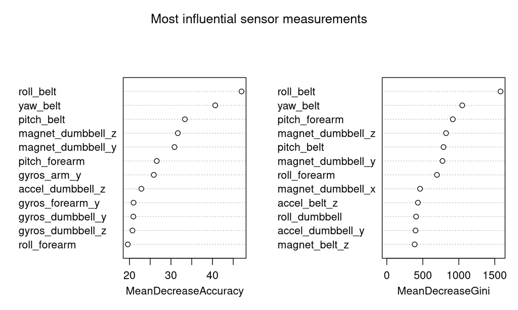

## Reproduce the analysis

Open this `.Rmd` in RStudio and click **Knit**. Running it again will use the same saved CSV files and random seed. Package versions used in this run: `caret` 7.0.1 and `randomForest` 4.6.14 on R version 4.0.0 (2020-04-24).